# HTTP Server Log

Vasudeo Maurya

25 September 2018

**Kint Opts**

**Load Libs**

```r
library(dplyr)
```

```r
library(stringr)
library(ggplot2)
library(wordcloud)
library(tidyverse)
```

**Read Data**

```r
dfrDataFile <- read_log("./data/apache_dataset.log",skip =0,col_names = FALSE)
head(dfrDataFile)
```

```
## # A tibble: 6 x 7
##   X1            X2    X3    X4             X5                    X6     X7
##   <chr>         <chr> <chr> <chr>          <chr>              <int>  <int>
## 1 202.32.92.47  <NA>  <NA>  01/Jun/1995:0~ GET /~scottp/publ~   200    271
## 2 ix-or7-27.ix~ <NA>  <NA>  01/Jun/1995:0~ GET /~ladd/ostric~   200 205908
## 3 ram0.huji.ac~ <NA>  <NA>  01/Jun/1995:0~ GET /~scottp/publ~   200    271
## 4 eagle40.sask~ <NA>  <NA>  01/Jun/1995:0~ GET /~lowey/         200   1116
## 5 eagle40.sask~ <NA>  <NA>  01/Jun/1995:0~ GET /~lowey/kevin~   200  49649
## 6 cdc8g5.cdc.p~ <NA>  <NA>  01/Jun/1995:0~ GET /~friesend/to~   200    461
```

**Rename Column**

```r
df <- rename(dfrDataFile, RemoteHost=X1,Id=X2,HTTPUser=X3,DateTime=X4,RequestLine=X5,StatusCode=X6,Size=X7)
```

**Dataframe Stucture**

```r
str(df)
```

```
## Classes 'tbl_df', 'tbl' and 'data.frame':    2408625 obs. of  7 variables:
##  $ RemoteHost : chr  "202.32.92.47" "ix-or7-27.ix.netcom.com" "ram0.huji.ac.il" "eagle40.sasknet.sk.ca" ...
##  $ Id         : chr  NA NA NA NA ...
##  $ HTTPUser   : chr  NA NA NA NA ...
##  $ DateTime   : chr  "01/Jun/1995:00:00:59 -0600" "01/Jun/1995:00:02:51 -0600" "01/Jun/1995:00:05:44 -0600" "01/Jun/1995:00:08:06 -0600" ...
##  $ RequestLine: chr  "GET /~scottp/publish.html" "GET /~ladd/ostriches.html" "GET /~scottp/publish.html" "GET /~lowey/" ...
##  $ StatusCode : int  200 200 200 200 200 200 200 200 200 200 ...
##  $ Size       : int  271 205908 271 1116 49649 461 5759 461 2460 2570 ...
##  - attr(*, "problems")=Classes 'tbl_df', 'tbl' and 'data.frame': 122 obs. of  5 variables:
##   ..$ row     : int  77360 77360 165543 165543 215236 215236 615749 615749 655737 655737 ...
##   ..$ col     : chr  "X6" NA "X6" NA ...
##   ..$ expected: chr  "an integer" "7 columns" "an integer" "7 columns" ...
##   ..$ actual  : chr  "HTTP/1.0\"" "8 columns" "HTTP/1.0\"" "8 columns" ...
##   ..$ file    : chr  "'./data/apache_dataset.log'" "'./data/apache_dataset.log'" "'./data/apache_dataset.log'" "'./data/apache_dataset.log'" ...
##  - attr(*, "spec")=List of 2
##   ..$ cols   :List of 7
##   .. ..$ X1: list()
##   .. .. ..- attr(*, "class")= chr  "collector_character" "collector"
##   .. ..$ X2: list()
##   .. .. ..- attr(*, "class")= chr  "collector_character" "collector"
##   .. ..$ X3: list()
##   .. .. ..- attr(*, "class")= chr  "collector_character" "collector"
##   .. ..$ X4: list()
##   .. .. ..- attr(*, "class")= chr  "collector_character" "collector"
##   .. ..$ X5: list()
##   .. .. ..- attr(*, "class")= chr  "collector_character" "collector"
##   .. ..$ X6: list()
##   .. .. ..- attr(*, "class")= chr  "collector_integer" "collector"
##   .. ..$ X7: list()
##   .. .. ..- attr(*, "class")= chr  "collector_integer" "collector"
##   ..$ default: list()
##   .. ..- attr(*, "class")= chr  "collector_guess" "collector"
##   ..- attr(*, "class")= chr "col_spec"
```

**Splitting Date and Time**

```r
Hours <- format(strptime(df$DateTime,"%d/%B/%Y:%H:%M:%S") ,format = "%H:%M:%S")
Dates <- format(strptime(df$DateTime,"%d/%B/%Y:%H:%M:%S") ,format = "%d/%b/%Y")
#adding Dates to df as column
df$Dates <- Dates
#adding Hours to df as column
df$Hours <- Hours
#Below outputs the dates in the international standard format
df$Dates=as.Date(df$Dates,"%d/%b/%Y")
##Dropping DateTime Column after splitting date and time from df
df <- subset( df, select = -DateTime)
head(df)
```

```
## # A tibble: 6 x 8
##   RemoteHost Id    HTTPUser RequestLine StatusCode   Size Dates      Hours
##   <chr>      <chr> <chr>    <chr>            <int>  <int> <date>     <chr>
## 1 202.32.92~ <NA>  <NA>     GET /~scot~        200    271 1995-06-01 00:0~
## 2 ix-or7-27~ <NA>  <NA>     GET /~ladd~        200 205908 1995-06-01 00:0~
## 3 ram0.huji~ <NA>  <NA>     GET /~scot~        200    271 1995-06-01 00:0~
## 4 eagle40.s~ <NA>  <NA>     GET /~lowe~        200   1116 1995-06-01 00:0~
## 5 eagle40.s~ <NA>  <NA>     GET /~lowe~        200  49649 1995-06-01 00:0~
## 6 cdc8g5.cd~ <NA>  <NA>     GET /~frie~        200    461 1995-06-01 00:1~
```

**Graph showing statuscode**

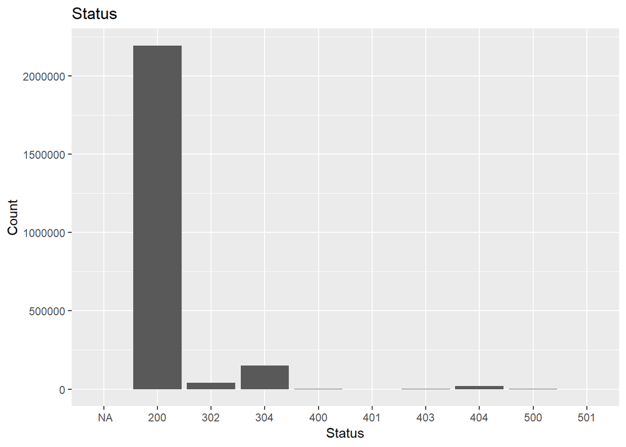

```r
ggplot(data=df, aes(x=format(StatusCode))) + geom_bar() + xlab("Status") + ylab("Count") + ggtitle("Status")
```

**Graph showing traffic to site**

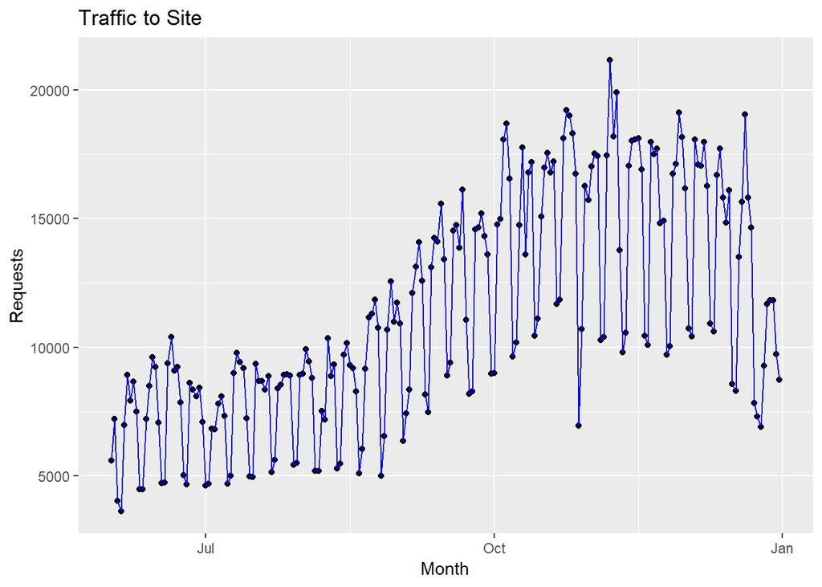

```r
reqs = as.data.frame(table(df$Dates))
ggplot(data = reqs, aes(x=as.Date(Var1), y=Freq)) + geom_point() + geom_line(colour = "blue") + xlab("Month") + ylab("Requests") + labs(title="Traffic to Site")
```

**Selecting data with successful statuscode**

```r
df_conn <- filter(df, StatusCode == "200")

#splitting date into day/month/year as separate column
df_conn <- data.frame(df_conn,
                    Year = as.numeric(format(df_conn$Dates, format = "%Y")),
                    Month = as.numeric(format(df_conn$Dates, format = "%m")),
                    Day = as.numeric(format(df_conn$Dates, format = "%d")))
head(df)
```

```
## # A tibble: 6 x 8
##   RemoteHost Id    HTTPUser RequestLine StatusCode   Size Dates      Hours
##   <chr>      <chr> <chr>    <chr>            <int>  <int> <date>     <chr>
## 1 202.32.92~ <NA>  <NA>     GET /~scot~        200    271 1995-06-01 00:0~
## 2 ix-or7-27~ <NA>  <NA>     GET /~ladd~        200 205908 1995-06-01 00:0~
## 3 ram0.huji~ <NA>  <NA>     GET /~scot~        200    271 1995-06-01 00:0~
## 4 eagle40.s~ <NA>  <NA>     GET /~lowe~        200   1116 1995-06-01 00:0~
## 5 eagle40.s~ <NA>  <NA>     GET /~lowe~        200  49649 1995-06-01 00:0~
## 6 cdc8g5.cd~ <NA>  <NA>     GET /~frie~        200    461 1995-06-01 00:1~
```

**Graph showing total hits per day**

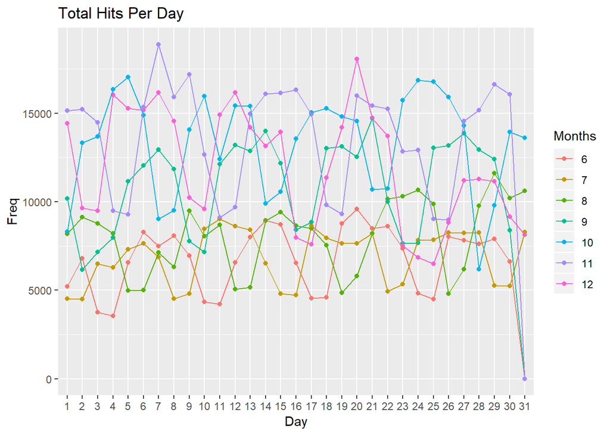

```r
thpd = as.data.frame(table(df_conn$Day,df_conn$Month))
thpd <- rename(thpd, Days=Var1,Months=Var2)
ggplot(data = thpd, aes(x=Days, y=Freq,group=Months,colour=Months)) + geom_point() + geom_line() + xlab("Day") + ylab("Freq") + labs(title="Total Hits Per Day")
```

**Graph showing Connection to Server Per Month**

```r
dfcts <- data.frame(table(df_conn$RemoteHost,df_conn$Month))
dfcts.Sort <- arrange(dfcts,desc(Freq))
dfcts.Sort <- rename(dfcts.Sort,Host=Var1,Month=Var2)
head(dfcts.Sort)
```

```
##                  Host Month Freq
## 1       duke.usask.ca    11 8848
## 2       duke.usask.ca    12 8830
## 3       duke.usask.ca     9 8398
## 4       duke.usask.ca    10 7766
## 5 freenet.buffalo.edu     7 7031
## 6       duke.usask.ca     6 6503
```

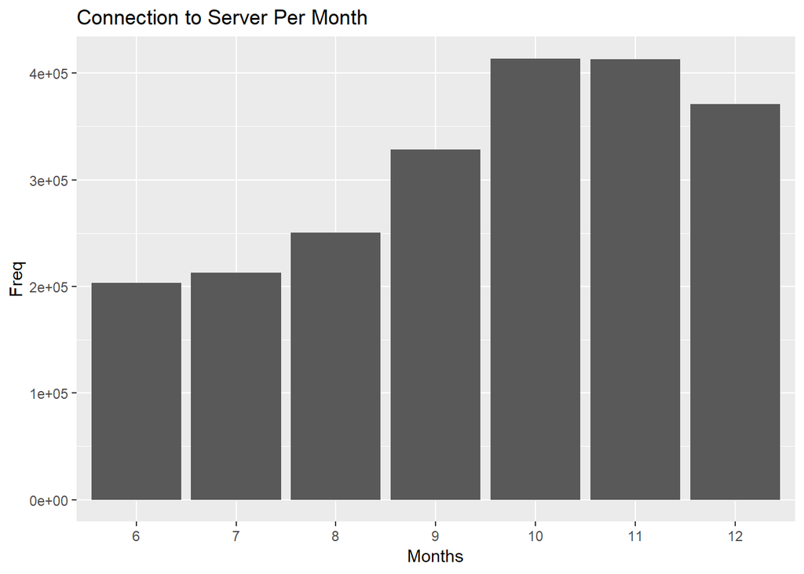

```r
ggplot(data = dfcts.Sort, aes(x=Month, y=Freq)) + geom_bar(stat = "identity") + xlab("Months") + ylab("Freq") + labs(title="Connection to Server Per Month")
```

**Page requested from server**

```r
dfreq <- data.frame(table(df_conn$RequestLine,df_conn$Month))
dfreq.Sort <- arrange(dfreq,desc(Freq))
dfreq.Sort <- rename(dfreq.Sort,Page=Var1,Month=Var2)
head(dfreq.Sort)
```

```
##                            Page Month  Freq
## 1                GET / HTTP/1.0    10 32768
## 2                GET / HTTP/1.0     9 29677
## 3                GET / HTTP/1.0    11 26802
## 4                GET / HTTP/1.0    12 23509
## 5 GET /images/logo.gif HTTP/1.0    10 20664
## 6                GET / HTTP/1.0     8 20259
```

**Data downloaded by each individual host**

```r
dfSize <- aggregate(Size ~ RemoteHost + Month, data = df_conn, sum)
dfSize <- filter(dfSize, !grepl("0",dfSize$Size))
dfSize.Sort <- arrange(dfSize,desc(Size))
head(dfSize.Sort)
```

```
##            RemoteHost Month     Size
## 1 freenet.buffalo.edu    11 44629591
## 2       duke.usask.ca    10 36418946
## 3 freenet.buffalo.edu     8 35146774
## 4     skynet.usask.ca    12 32148431
## 5    sailor.lib.md.us    11 29548579
## 6       igor.usask.ca     6 27827299
```

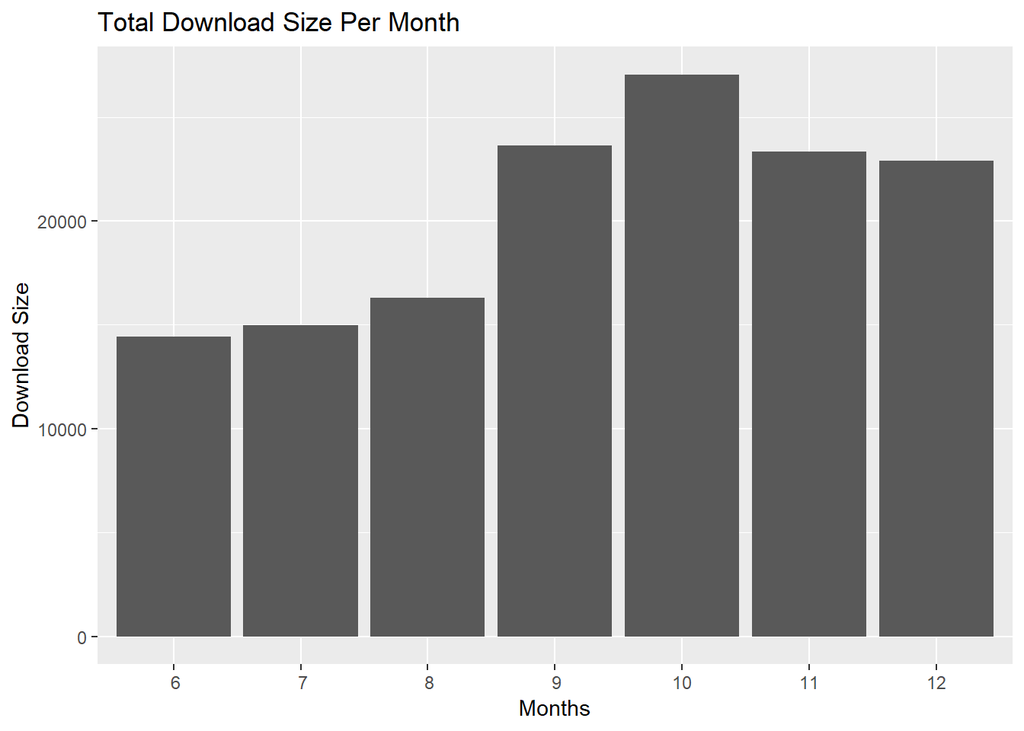

```r
ggplot(data=dfSize.Sort, aes(x=format(Month))) + geom_bar() + xlab("Months") + ylab("Download Size") + ggtitle("Total Download Size Per Month")
```

**Download Size Per Day**

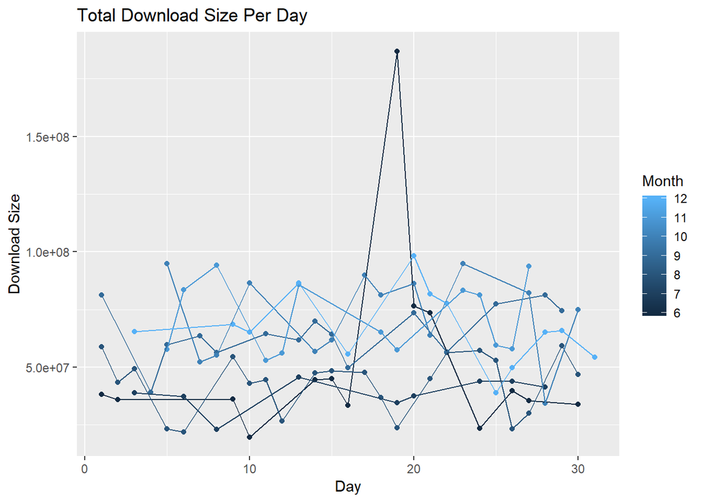

```r
dfSizepd <- aggregate(Size ~ Day + Month, data = df_conn, sum)
dfSizepd <- filter(dfSizepd, !grepl("0",dfSizepd$Size))
ggplot(data = dfSizepd, aes(x=Day, y=Size,group=Month,colour=Month)) + geom_point() + geom_line() + xlab("Day") + ylab("Download Size") + labs(title="Total Download Size Per Day")
```

```r
dfPageSize <- aggregate(Size ~ RequestLine + Month, data = df_conn, sum)
dfPageSize <- filter(dfPageSize, !grepl("0",dfPageSize$Size))
dfPageSize.Sort <- arrange(dfPageSize,desc(Size))
head(dfPageSize.Sort)
```

```
##                          RequestLine Month      Size
## 1             GET /~scottp/free.html    11 371154124
## 2 GET /uofs/ivany_movie.mov HTTP/1.0     6 234787776
## 3             GET /~scottp/free.html     9 181466121
## 4 GET /education/edbldg.gif HTTP/1.0    10  89161792
## 5                     GET / HTTP/1.0    12  83338372
## 6            GET /~scottp/free.html/    12  81273684
```

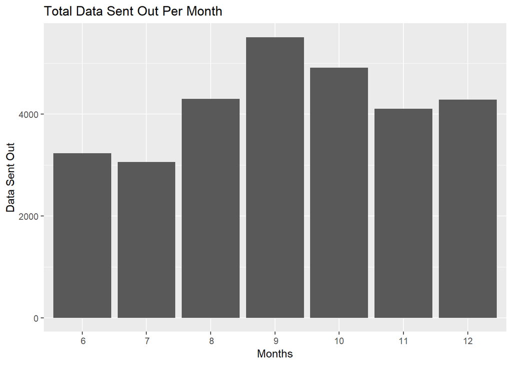

```r
ggplot(data=dfPageSize.Sort, aes(x=format(Month))) + geom_bar() + xlab("Months") + ylab("Data Sent Out") + ggtitle("Total Data Sent Out Per Month")
```

**Which host has connected the maximum number of times to our server? Give the host name & count of connections from that host.**

```r
RemoteHost.Sort <- data.frame(table(df_conn$RemoteHost))
r <- arrange(RemoteHost.Sort,desc(Freq))
head(r)
```

```
##                           Var1  Freq
## 1                duke.usask.ca 49740
## 2          freenet.buffalo.edu 29183
## 3                sask.usask.ca 26863
## 4 broadway.sfn.saskatoon.sk.ca 20823
## 5             moondog.usask.ca 12915
## 6   srv1.freenet.calgary.ab.ca 11839
```

```r
max(r$Freq)
```

```
## [1] 49740
```

**Which page that has been requested the maximum number of times from our server? Give the page name & count of the times the page was requested.**

```r
RequestLine.Sort <-data.frame(table(df_conn$RequestLine))
r <- arrange(RequestLine.Sort,desc(Freq))
r <- filter(r, !grepl("GET / HTTP/1.0",r$Var1))
head(r)
```

```
##                               Var1  Freq
## 1    GET /images/logo.gif HTTP/1.0 92302
## 2           GET /~scottp/free.html 78487
## 3 GET /images/logo_32.gif HTTP/1.0 35025
## 4        GET /~scottp/freetel.html 22930
## 5   GET /cgi-bin/hytelnet HTTP/1.0 22462
## 6          GET /~scottp/free.html/ 22200
```

```r
max(r$Freq)
```

```
## [1] 92302
```

**How many unique hosts have connected to our server? Give counts.**

```r
length(unique(df_conn$RemoteHost))
```

```
## [1] 157358
```

**How many unique pages have been requested from our server? Give counts.**

```r
length(unique(df_conn$RequestLine))
```

```
## [1] 20303
```

**Which page has caused maximum data transfer from our server? Give page name & the data transfer for the page.**

```r
r <- summarise(group_by(dfPageSize, RequestLine), sum(Size))
r <- arrange(r,desc(`sum(Size)`))
r$RequestLine[1]
```

```
## [1] "GET /~scottp/free.html"
```

```r
max(r$`sum(Size)`)
```

```
## [1] 624002736
```

**Which host has caused maximum data transfer from our server? Give host name & the data transfer for the host.**

```r
r <- summarise(group_by(df_conn,RemoteHost ), sum(Size))
#r <- filter(r, !grepl(0,r$`sum(Size)`))
r <- arrange(r,desc(`sum(Size)`))
r$RemoteHost[1]
```

```
## [1] "freenet.buffalo.edu"
```

```r
head(r)
```

```
## # A tibble: 6 x 2
##   RemoteHost                   `sum(Size)`
##   <chr>                              <int>
## 1 freenet.buffalo.edu            305054357
## 2 duke.usask.ca                  274850271
## 3 broadway.sfn.saskatoon.sk.ca   135494706
## 4 ccn.cs.dal.ca                  115300684
## 5 srv1.freenet.calgary.ab.ca     111176474
## 6 sask.usask.ca                  101346902
```

**Which page has maximum download size from our server? Give page name & the size for the page.**

```r
s <- dfPageSize.Sort$RequestLine[1]
s
```

```
## [1] "GET /~scottp/free.html"
```

```r
dfPageSize.Sort$Size[1]
```

```
## [1] 371154124
```

**What is the download count of the page that has maximum download size from our server? Give page name & download count**

```r
cnt_s <- filter(dfPageSize.Sort, grepl(s,dfPageSize.Sort$RequestLine))
s
```

```
## [1] "GET /~scottp/free.html"
```

```r
nrow(cnt_s)
```

```
## [1] 8
```

**Which page has minimum download size from our server? Give page name & the size for the page.**

```r
dfAscSize.Sort <- arrange(dfPageSize,Size)
m <- dfAscSize.Sort$RequestLine[1]
m
```

```
## [1] "GET /digger/ HTTP/1.0"
```

```r
dfAscSize.Sort$Size[1]
```

```
## [1] 1
```

**What is the download count of the page that minimum download size from our server? Give page name & the size for the page.**

```r
cnt_m <- filter(dfAscSize.Sort, grepl(m,dfAscSize.Sort$RequestLine))
nrow(cnt_m)
```

```
## [1] 2
```

```r
m
```

```
## [1] "GET /digger/ HTTP/1.0"
```

```r
dfAscSize.Sort$Size[1]
```

```
## [1] 1
```